# Tarea 7

Diego Abarca, Fernando Carmona

2024-10-31

```r
library(ggpubr)
library("BSDA")
library(summarytools)
library(DT)
library(dplyr)
library(psych)
```

# *tarea 7:*

## 1° parte

### a) Defina las hipótesis a contrastar.

Como la hipótesis planteada es que el mejor tiempo medio de los atletas de raza Negra después de ingresar al programa de entrenamiento es mayor a 12.4 segundos.

Entonces hipótesis nula es : Ho: mu >= 12.4seg

```r
Test_Velocidad_Negra <- read.csv2("data.csv")

Test_Velocidad_Negra =  Test_Velocidad_Negra[Test_Velocidad_Negra$Raza =="Negra",]

DEntrenamiento = Test_Velocidad_Negra[,4]

Metricas = describe(DEntrenamiento,IQR=T,quant=c(.25,.50,.75))

Metricas
```

```
##    vars  n  mean   sd median trimmed mad   min   max range skew kurtosis   se
## X1    1 28 12.55 1.26  12.42   12.46   1 10.69 15.99   5.3  0.7     0.27 0.24
##     IQR Q0.25  Q0.5 Q0.75
## X1 1.27 11.82 12.42 13.09
```

### b) Proponga un procedimiento adecuado para el análisis.

Primero analizar que tipo de test es el adecuado para analizar la vericidad de la afirmación que se muestra en el enunciado. para eso primero analizamos los datos que tenemos:

#### 1) Análisis de la distribución de los datos

```r
v.test <- shapiro.test(DEntrenamiento)
v.test
```

```
##
##  Shapiro-Wilk normality test
##
## data:  DEntrenamiento
## W = 0.95201, p-value = 0.2225
```

El valor del p-value resultante es mayor a 0.05, lo que sugiere que los datos siguen probablemente una distribución normal. El test de Shapiro-Wilk evalúa la hipótesis nula de que los datos provienen de una distribución normal, y dado que no rechazamos esta hipótesis, concluimos que la distribución es probablemente normal. Esta conclusión se refuerza aún más con la gráfica generada a continuación.

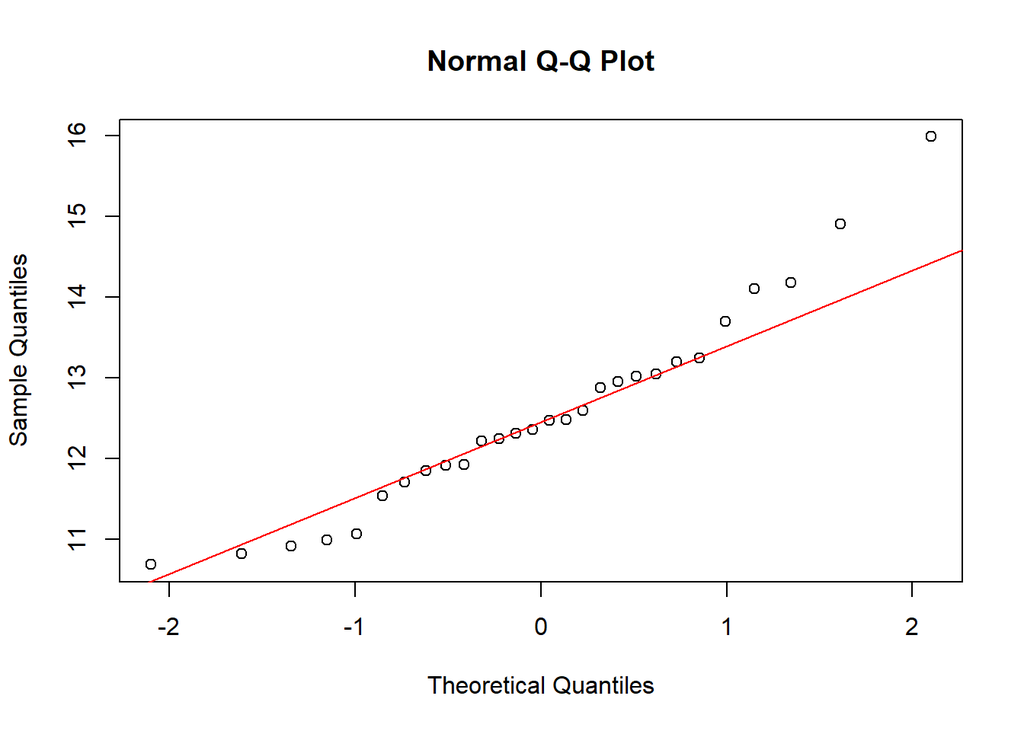

```r
# QQ-plot
qqnorm(DEntrenamiento)
qqline(DEntrenamiento, col = "red")  # Agregar la línea de referencia
```

Como se puede observar, los puntos en el gráfico siguen una línea de tendencia recta, lo que hace más probable que los datos sigan una distribución normal.

#### 2) Tamaño de la muestra y conocimiento sobre la varianza o la desviación estandar

El siguiente paso es verificar el tamaño de la muestra y determinar si conocemos la varianza o la desviación tanto poblacional o muestral. En este caso, sabemos que la muestra tiene menos de 30 datos (28) y no se conoce la varianza poblacional pero si podemos obtener la varianza o desviación muestral que en este caso seria 1.26

#### Conclusión del análisis

Con estos análisis en mano, podemos concluir que el test adecuado para analizar la veracidad de la afirmación es el t-test. Esto es posible porque cumplimos con todas las condiciones necesarias: la muestra es pequeña (menos de 30 datos), conocemos la desviación muestral y los datos siguen una probable distribución normal.

### C) Verifique las condiciones necesarias del procedimiento y ejecútelo.

#### Datos:

μ = ¿?

σ = 1.26

n = 28

```r
t = t.test(DEntrenamiento,y=NULL, alternative = "less", mu = 12.4, conf.level=0.95)
t
```

```
##
##  One Sample t-test
##
## data:  DEntrenamiento
## t = 0.62078, df = 27, p-value = 0.73
## alternative hypothesis: true mean is less than 12.4
## 95 percent confidence interval:
##      -Inf 12.95154
## sample estimates:
## mean of x
##  12.54732
```

## 2° parte

### a)

Según el dataset de notas de los alumnos de ingeniería, se afirma que las notas de la media de los estudiantes que cursaron cálculo en el semestre 2024-1 es una nota aprovatoría. ¿ Es está afirmación correcta ?

### b)

Variable a medir será las notas de los estudiantes de ingenería en cálculo del semestre 2024-1.

### c)

La muestra seran las notas finales de los estudiantes de ingeniería en cálculo del semestre 2024-1.

### d)

La hipótesis nula será que la media de los estudiantes de ingenería del semestre 2024-1 es mayor o igual a 4. Expresada matemáticamente como: Ho: mu >= 4.

Por tanto, la hipótesis alternativa será que la media de las notas es menor a 4 Expresado matemáticamente como: Ha: mu < 4

#### 3 parte

El error tipo 1 es el error cuando se encuentra un falso positivo, cuando se acepta la hipótesis nula cuando esta se debería rechazar, María estaba en lo correcto. Mientras que el error tipo 2, es un falso negativo, cuando se rechaza la hipótesis nula y se acepta la alternativa cuando la nula era verdader, José estraba incorrecto.